# Take-Home Midterm Exam

```r
dim(topmovies)
```

```
## [1] 10  3
```

- **Question 2 (10 pts)** Now let’s see how a movie’s genre relates to the user rating and a few other variables. Show the average and median `UserRatings`, `NumRaters` and `GrossUS` of each `Genre`. Round your average ratings to 2 decimal points and order the results by highest average ratings. **Victory conditions**: Your code returns a data frame with dimensions 16 x 7 and, ordered by the highest average ratings. All Columns have short but clear names

```r
movie %>% group_by(Genre) %>% select("UserRating", "NumRaters","GrossUS") %>%  summarise_each(funs(mean,median))%>%  arrange(desc(UserRating_mean)) %>% mutate_if(is.numeric, ~round(., 2))
```

```
## # A tibble: 16 x 7
##    Genre UserRating_mean NumRaters_mean GrossUS_mean UserRating_medi…
##    <fct>           <dbl>          <dbl>        <dbl>            <dbl>
##  1 Other            8.32        259399.    14544302.             8.3
##  2 Film…            8.06         96142.     3221405.             8
##  3 Drama            7.98        213188.    29805923.             8
##  4 Myst…            7.91        254791.    36903726.             7.85
##  5 Fant…            7.9         439484.   154454050.             7.8
##  6 Sci-…            7.89        486477.   115175132.             7.9
##  7 Anim…            7.86        281873.   126043673.             7.8
##  8 Adve…            7.85        192730.    48663223.             7.9
##  9 Musi…            7.84        109312.    34351977.             7.8
## 10 Acti…            7.83        299245.    88258943.             7.8
## 11 Biog…            7.83        208523.    51427664              7.8
## 12 Roma…            7.8         177219.    41337575.             7.7
## 13 Crime            7.8         250719.    38911784.             7.7
## 14 Thri…            7.78        177308.    25042625.             7.7
## 15 Come…            7.75        142233.    40452159.             7.7
## 16 Horr…            7.7         176533.    25511535.             7.6
## # … with 2 more variables: NumRaters_median <dbl>, GrossUS_median <dbl>
```

- **Question 3 (15 pts)** Next, let’s try some data transformations to create new predictors. Create two new columns for the log of `NumRaters` and the log of `GrossUS`, called `log_NumRaters` and `log_GrossUS`. (a) Visualize the distributions of `log_NumRaters` and `log_GrossUS`. (b) Plot the relationship between `log_NumRaters` and `log_GrossUS`, and differentiate movies by their `ContentRating`. **Victory conditions**:(a) You have two plots showing two different probability distributions, each with clearly labeled axes and reasonable precision. (b) You have one plot showing relationships between all the variables of interest.
- *Hint*: `log` function in R takes the log of a value.

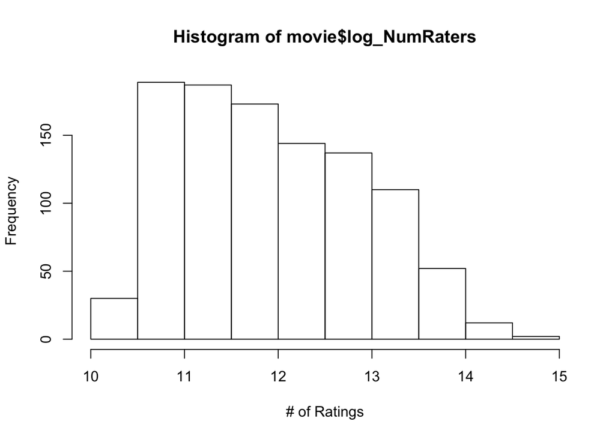

```r
movie<- movie %>% mutate(log_NumRaters = log(NumRaters), log_GrossUS = log(GrossUS))

hist(movie$log_NumRaters, xlab = "# of Ratings")
```

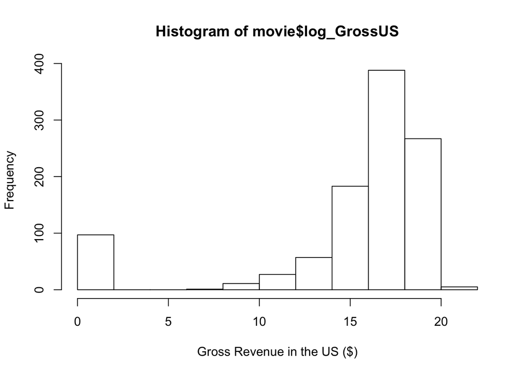

```r
hist(movie$log_GrossUS, xlab = "Gross Revenue in the US ($)")
```

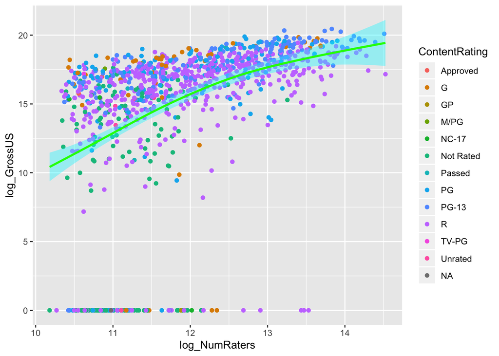

```r
movie %>% ggplot(movie, mapping = aes(log_NumRaters,log_GrossUS))+ geom_point(mapping = aes(color=ContentRating))+geom_smooth(color = "green", fill= "turquoise1")
```

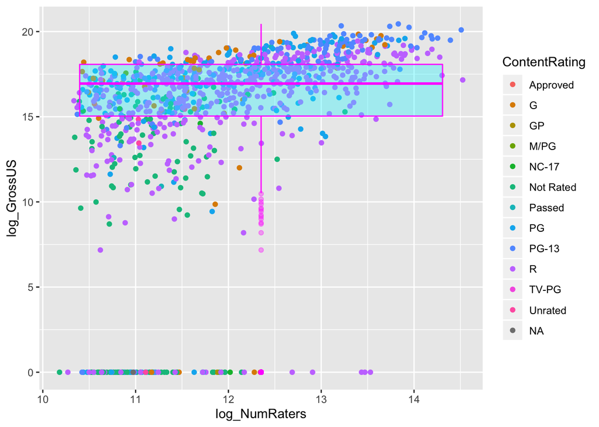

```r
movie %>% ggplot(movie, mapping = aes(log_NumRaters,log_GrossUS))+ geom_point(mapping = aes(color=ContentRating))+geom_boxplot(color = "magenta", fill = "turquoise1", alpha = 0.35)
```

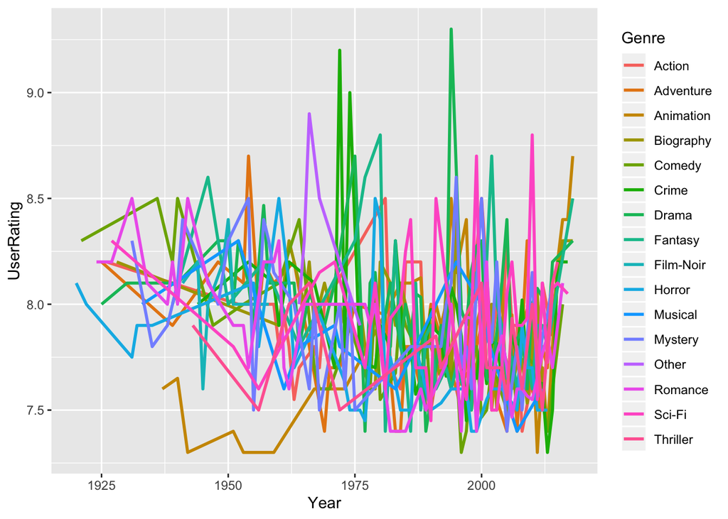

```r
#Bonus plot. Please disregard.
movie %>% ggplot(movie, mapping = aes(x=Year, y=UserRating,colour=Genre,group=Genre)) + stat_summary(fun.y="mean", geom="smooth")
```

- **Question 4 (15 pts)** Consider breaking the year a movie is released into decades. (a) How many movies are in each decade? (b) plot the distribution of user ratings over different decades (c) Comment on movies from which decade has the highest average ratings, which decades has the lowest among the highest rated movies. **Victory conditions**: Your column for decades is a factor/character column instead of numeric/integer. You have ten subplots showing ten different decades, with clearly labeled axes and reasonable precision.

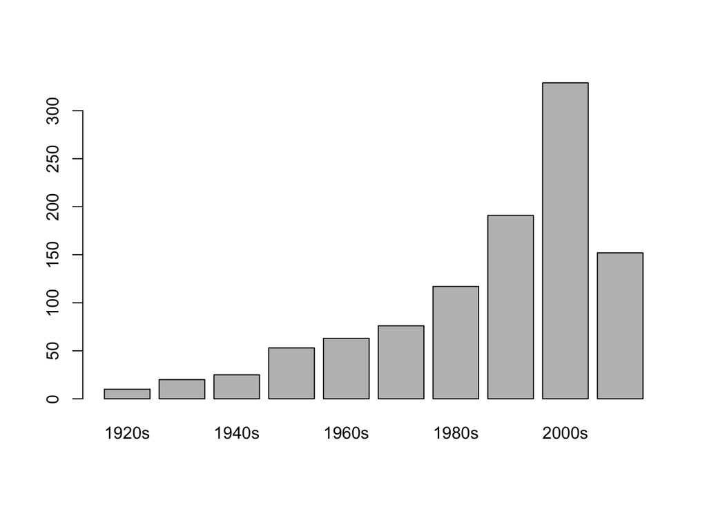

```r
YearToDecade = function(year){
  if(year >= 1920 && year < 1930) return("1920s")
  if(year >= 1930 && year < 1940) return("1930s")
  if(year >= 1940 && year < 1950) return("1940s")
  if(year >= 1950 && year < 1960) return("1950s")
  if(year >= 1960 && year < 1970) return("1960s")
  if(year >= 1970 && year < 1980) return("1970s")
  if(year >= 1980 && year < 1990) return("1980s")
  if(year >= 1990 && year < 2000) return("1990s")
  if(year >= 2000 && year < 2010) return("2000s")
  if(year >= 2010) return("2010s")
  return("Other")
}

movie$Decade = factor(sapply(movie$Year, YearToDecade),                              levels=c("1920s","1930s","1940s","1950s","1960s","1970s","1980s","1990s","2000s","2010s"))

plot(movie$Decade)
```

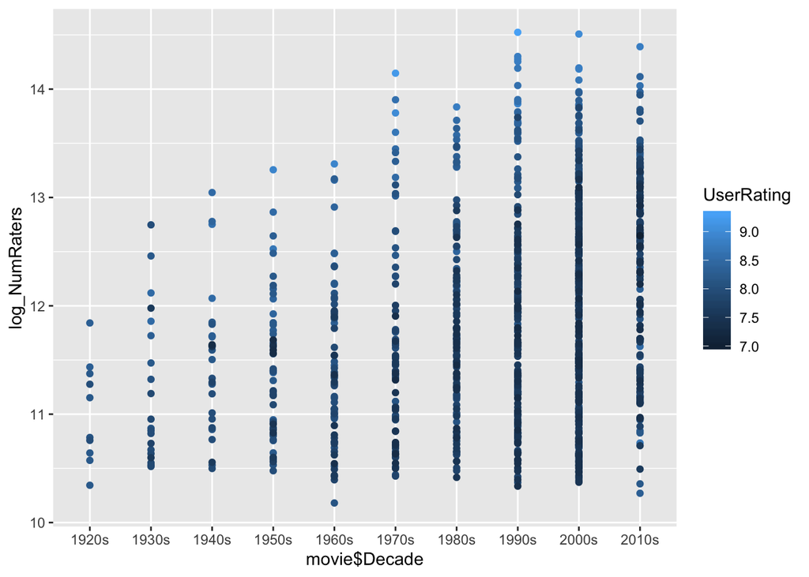

```r
movie %>% ggplot(movie,mapping=aes(movie$Decade,log_NumRaters))+geom_point(mapping= aes(color = UserRating))
```

```r
movie %>% count(Decade)
```

```
## # A tibble: 10 x 2
##    Decade     n
##    <fct>  <int>
##  1 1920s     10
##  2 1930s     20
##  3 1940s     25
##  4 1950s     53
##  5 1960s     63
##  6 1970s     76
##  7 1980s    117
##  8 1990s    191
##  9 2000s    329
## 10 2010s    152
```

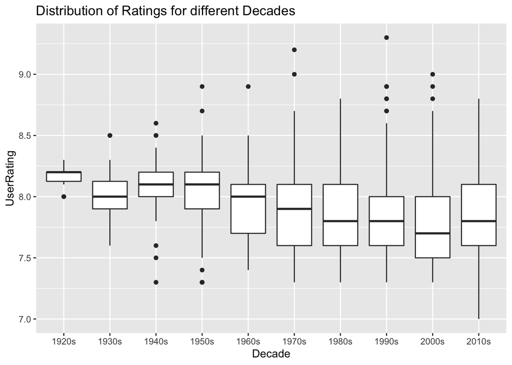

```r
ggplot(movie, mapping = aes(x = Decade, y = UserRating)) + geom_boxplot() + ggtitle("Distribution of Ratings for different Decades")
```

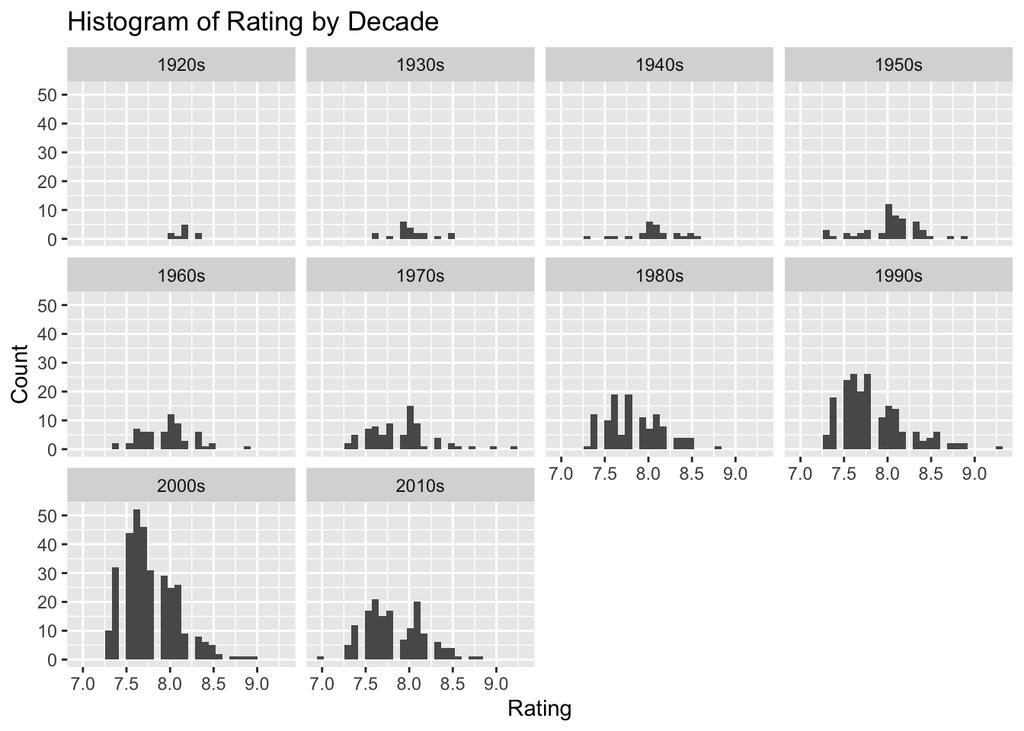

```r
ggplot(movie, mapping = aes(x = UserRating)) +geom_histogram(bins = 30)+
  facet_wrap(~Decade) +
  ggtitle("Histogram of Rating by Decade") +
  xlab("Rating") +
  ylab("Count")
```

```r
#The code below can be used to find the average ratings for a given decade.
movie %>% filter(Decade == "1920s") %>% summary()
```

```
##                          Title        Year         RunTime
##  Battleship Potemkin        :1   Min.   :1920   Min.   : 45.00
##  Metropolis                 :1   1st Qu.:1922   1st Qu.: 69.75
##  Nosferatu                  :1   Median :1925   Median : 85.00
##  Sherlock Jr.               :1   Mean   :1924   Mean   : 87.70
##  Sunrise                    :1   3rd Qu.:1927   3rd Qu.: 94.75
##  The Cabinet of Dr. Caligari:1   Max.   :1928   Max.   :153.00
##  (Other)                    :4
##    ContentRating   UserRating      Metascore    NumRaters
##  Not Rated:8     Min.   :8.000   Min.   :98   Min.   : 31069
##  Passed   :2     1st Qu.:8.125   1st Qu.:98   1st Qu.: 43150
##  Approved :0     Median :8.200   Median :98   Median : 59009
##  G        :0     Mean   :8.170   Mean   :98   Mean   : 67446
##  GP       :0     3rd Qu.:8.200   3rd Qu.:98   3rd Qu.: 84992
##  M/PG     :0     Max.   :8.300   Max.   :98   Max.   :138925
##  (Other)  :0                     NA's   :9
##        Genre       Budget          GrossUS         GrossGlobal
##  Horror   :2   Min.   :     1   Min.   :      1   Min.   :1
##  Romance  :2   1st Qu.:     1   1st Qu.:      1   1st Qu.:1
##  Action   :1   Median :     1   Median :  36424   Median :1
##  Adventure:1   Mean   :194101   Mean   :1318639   Mean   :1
##  Biography:1   3rd Qu.:192000   3rd Qu.:1171468   3rd Qu.:1
##  Comedy   :1   Max.   :923000   Max.   :5450000   Max.   :1
##  (Other)  :2
##                Director1             Director2               Actor1
##  Charles Chaplin    :2   Buster Keaton    :1   Buster Keaton    :2
##  F.W. Murnau        :2   \xcd_ric Toledano:0   Charles Chaplin  :2
##  Buster Keaton      :1   Adrian Molina    :0   Aleksandr Antonov:1
##  Carl Theodor Dreyer:1   Alan Mak         :0   Brigitte Helm    :1
##  Clyde Bruckman     :1   Allen Hughes     :0   George O'Brien   :1
##  Fritz Lang         :1   (Other)          :0   Maria Falconetti :1
##  (Other)            :2   NA's             :9   (Other)          :2
##                Actor2                    Actor3  log_NumRaters
##  Alexander Granach:1   Andrͩ Berley          :1   Min.   :10.34
##  Alfred Abel      :1   Friedrich Feher      :1   1st Qu.:10.67
##  Conrad Veidt     :1   Glen Cavender        :1   Median :10.97
##  Edna Purviance   :1   Grigoriy Aleksandrov :1   Mean   :11.02
##  Eugene Silvain   :1   Gustav Fr\xcd_hlich  :1   3rd Qu.:11.35
##  Janet Gaynor     :1   Gustav von Wangenheim:1   Max.   :11.84
##  (Other)          :4   (Other)              :4
##   log_GrossUS         Decade
##  Min.   : 0.000   1920s  :10
##  1st Qu.: 0.000   1930s  : 0
##  Median :10.416   1940s  : 0
##  Mean   : 7.967   1950s  : 0
##  3rd Qu.:13.969   1960s  : 0
##  Max.   :15.511   1970s  : 0
##                   (Other): 0
```

```r
#Looks like we had fewer movies in the 1920s but those movies were high quality (according to the ratings). As you can see, the highest average rating was in th 1920s (8.17). Overtime, there has been a trend towards "quantity over quality" in movies.

#Of the top 10 movies, 2010 is the decade with lowest average rating. 2010 only appears once, at the bottom of top 10.

movie %>% group_by(Decade) %>% select("Decade","UserRating") %>% head(10)
```

```
## # A tibble: 10 x 2
## # Groups:   Decade [6]
##    Decade UserRating
##    <fct>       <dbl>
##  1 1990s         9.3
##  2 1970s         9.2
##  3 2000s         9
##  4 1970s         9
##  5 1990s         8.9
##  6 2000s         8.9
##  7 1990s         8.9
##  8 1960s         8.9
##  9 1950s         8.9
## 10 2010s         8.8
```

- **Question 5 (15 pts)** Now we take a look at the finances of these movies. Create a new variable `BreakEven`, if a movie has **either** its gross US box office or its gross global box office larger than the budget, we will give 1 for `BreakEven` otherwise 0. (a) What is the average user ratings for movies that made a profit versus those didn’t? (b) Calculate the proportion of movies that are profitable at each decade. (c) Comment on how the likelihood of being profitable change over the decades? **Victory conditions**: You have a data frame showing percentages of profitable movies for each decade. Your comment is clear and concise.

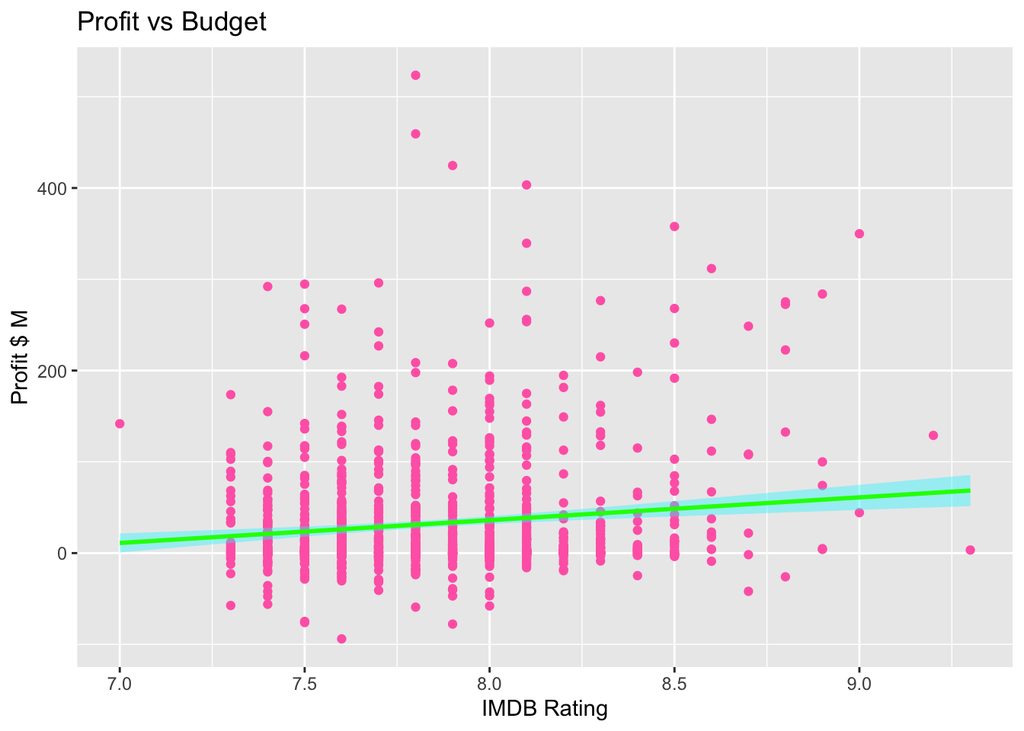

```r
movie<- movie %>% mutate(Profit = GrossUS-Budget, BreakEven = ifelse(Profit>=0,1,0))

#Let me first visualise the distribution of profits. Looks like higher IMDB ratings are ever so slightly predictive of higher profit.
movie %>% ggplot(aes(x=UserRating, y=(Profit)/1000000))+
        geom_point(color = "hotpink")+
        geom_smooth(method='lm',color = "green", fill = "turquoise1")+
        labs(x="IMDB Rating", y="Profit $ M", title="Profit vs Budget")
```

```r
movie %>% filter(BreakEven > 0) %>% summary()
```

```
##                   Title          Year         RunTime        ContentRating
##  Dawn of the Dead    :  2   Min.   :1921   Min.   : 45.0   R        :374
##  Les Miserables      :  2   1st Qu.:1980   1st Qu.:102.0   PG-13    :153
##  True Grit           :  2   Median :1997   Median :116.0   PG       :121
##  (500) Days of Summer:  1   Mean   :1991   Mean   :120.8   Not Rated: 95
##  [Rec]               :  1   3rd Qu.:2006   3rd Qu.:134.0   G        : 41
##  12 Angry Men        :  1   Max.   :2018   Max.   :321.0   (Other)  : 21
##  (Other)             :798                  NA's   :5       NA's     :  2
##    UserRating      Metascore        NumRaters             Genre
##  Min.   :7.000   Min.   : 28.00   Min.   :  26379   Crime    :117
##  1st Qu.:7.600   1st Qu.: 68.00   1st Qu.:  72116   Drama    : 95
##  Median :7.800   Median : 77.00   Median : 150086   Romance  : 91
##  Mean   :7.857   Mean   : 76.09   Mean   : 269231   Biography: 83
##  3rd Qu.:8.100   3rd Qu.: 85.00   3rd Qu.: 367100   Comedy   : 59
##  Max.   :9.300   Max.   :100.00   Max.   :2031388   Animation: 56
##                  NA's   :96                         (Other)  :306
##      Budget             GrossUS           GrossGlobal
##  Min.   :        1   Min.   :        1   Min.   :1.000e+00
##  1st Qu.:        1   1st Qu.:  5956560   1st Qu.:1.000e+00
##  Median :  7000000   Median : 33395426   Median :2.190e+07
##  Mean   : 24737906   Mean   : 69362444   Mean   :1.397e+08
##  3rd Qu.: 28000000   3rd Qu.: 88120539   3rd Qu.:1.634e+08
##  Max.   :321000000   Max.   :760507625   Max.   :2.788e+09
##
##              Director1                Director2                 Actor1
##  Alfred Hitchcock : 14   Ethan Coen        :  5   Tom Hanks        : 11
##  Steven Spielberg : 13   Joel Coen         :  3   Clint Eastwood   : 10
##  Martin Scorsese  :  9   Wilfred Jackson   :  3   Al Pacino        :  9
##  Christopher Nolan:  8   Chris Renaud      :  2   Denzel Washington:  8
##  Clint Eastwood   :  8   Christopher Miller:  2   James Stewart    :  8
##  Stanley Kubrick  :  8   (Other)           : 54   Robert De Niro   :  8
##  (Other)          :747   NA's              :738   (Other)          :753
##                Actor2                   Actor3    log_NumRaters
##  Emma Watson      :  7   Rupert Grint      :  6   Min.   :10.18
##  Geoffrey Rush    :  5   Carrie Fisher     :  4   1st Qu.:11.19
##  Matt Damon       :  5   Scarlett Johansson:  4   Median :11.92
##  Christopher Lloyd:  4   Anna Kendrick     :  3   Mean   :12.01
##  Ian McKellen     :  4   Catherine Keener  :  3   3rd Qu.:12.81
##  Julie Delpy      :  4   Jack Nicholson    :  3   Max.   :14.52
##  (Other)          :778   (Other)           :784
##   log_GrossUS        Decade        Profit            BreakEven
##  Min.   : 0.00   2000s  :237   Min.   :        0   Min.   :1
##  1st Qu.:15.60   1990s  :151   1st Qu.:  3140262   1st Qu.:1
##  Median :17.32   2010s  :125   Median : 19501237   Median :1
##  Mean   :15.96   1980s  : 96   Mean   : 44624538   Mean   :1
##  3rd Qu.:18.29   1970s  : 68   3rd Qu.: 52175155   3rd Qu.:1
##  Max.   :20.45   1960s  : 53   Max.   :523507625   Max.   :1
##                  (Other): 77
```

```r
#Profitable movies had an average rating of 7.857.
movie %>% filter(BreakEven <= 0) %>% summary()
```

```
##                    Title          Year         RunTime
##  2046                 :  1   Min.   :1920   Min.   : 64.0
##  21 Grams             :  1   1st Qu.:1984   1st Qu.:102.8
##  3-Iron               :  1   Median :2000   Median :119.0
##  3:10 to Yuma         :  1   Mean   :1991   Mean   :121.4
##  A Bronx Tale         :  1   3rd Qu.:2007   3rd Qu.:134.0
##  A History of Violence:  1   Max.   :2018   Max.   :242.0
##  (Other)              :223                  NA's   :1
##    ContentRating   UserRating      Metascore        NumRaters
##  R        :118   Min.   :7.300   Min.   : 31.00   Min.   :  32705
##  PG-13    : 35   1st Qu.:7.600   1st Qu.: 62.00   1st Qu.:  55962
##  Not Rated: 33   Median :7.800   Median : 73.00   Median : 102734
##  PG       : 25   Mean   :7.817   Mean   : 72.26   Mean   : 158568
##  G        :  8   3rd Qu.:8.000   3rd Qu.: 82.75   3rd Qu.: 195475
##  (Other)  :  9   Max.   :8.800   Max.   :100.00   Max.   :1625512
##  NA's     :  1                   NA's   :43
##        Genre        Budget             GrossUS
##  Crime    :36   Min.   :    18000   Min.   :        1
##  Drama    :27   1st Qu.:  3251794   1st Qu.:    49034
##  Biography:23   Median : 14000000   Median :  4971340
##  Romance  :18   Mean   : 26798269   Mean   : 15533388
##  Sci-Fi   :17   3rd Qu.: 31000000   3rd Qu.: 19202743
##  Comedy   :16   Max.   :260000000   Max.   :200821936
##  (Other)  :92
##   GrossGlobal                   Director1           Director2
##  Min.   :        1   Hayao Miyazaki  :  5   Ethan Coen   :  3
##  1st Qu.:        1   Martin Scorsese :  5   Alan Mak     :  1
##  Median :        1   David Fincher   :  4   Buster Keaton:  1
##  Mean   : 41457778   Woody Allen     :  4   Byron Howard :  1
##  3rd Qu.: 42345360   Akira Kurosawa  :  3   Eli Roth     :  1
##  Max.   :591794936   Alfred Hitchcock:  3   (Other)      :  6
##                      (Other)         :205   NA's         :216
##                Actor1                  Actor2                  Actor3
##  Johnny Depp      :  6   Kate Winslet     :  3   Jennifer Connelly:  3
##  Christian Bale   :  5   Albert Finney    :  2   Chiwetel Ejiofor :  2
##  Robert De Niro   :  5   Ben Kingsley     :  2   Ed Harris        :  2
##  Russell Crowe    :  5   Benicio Del Toro :  2   Emily Watson     :  2
##  Humphrey Bogart  :  4   Cate Blanchett   :  2   Liam Neeson      :  2
##  Leonardo DiCaprio:  4   Catherine Deneuve:  2   Adolphe Menjou   :  1
##  (Other)          :200   (Other)          :216   (Other)          :217
##  log_NumRaters    log_GrossUS        Decade       Profit
##  Min.   :10.40   Min.   : 0.00   2000s  :92   Min.   :-93990787
##  1st Qu.:10.93   1st Qu.:10.80   1990s  :40   1st Qu.:-14485483
##  Median :11.54   Median :15.42   2010s  :27   Median : -4733029
##  Mean   :11.63   Mean   :12.31   1980s  :21   Mean   :-11264881
##  3rd Qu.:12.18   3rd Qu.:16.77   1950s  :15   3rd Qu.: -1499999
##  Max.   :14.30   Max.   :19.12   1960s  :10   Max.   :    -9225
##                                  (Other):24
##    BreakEven
##  Min.   :0
##  1st Qu.:0
##  Median :0
##  Mean   :0
##  3rd Qu.:0
##  Max.   :0
##
```